# Data

Booklet I [*D*-score: Turning milestones into measurement](https://stefvanbuuren.name/dbook1/) highlighted the concepts and tools needed to obtain a quantitative score from milestones from an instrument. Once we have such a score, we may

- Compare development within the same child over time;
- Compare development of two children of the same age;
- Compare development of two children at different ages;
- Compare development of groups of children at different ages;
- And so on…

In practice, the problem is more complicated. There are about 150 different instruments to measure child development. [@fernald2017toolkit]

In principle, one could apply the methodology of booklet I to each instrument separately. Every instrument would thus define its own quantitative scale. The problem with this approach is that measurements made on those scales cannot be compared to each other. More in particular, scores will be specific to the milestones, study samples, and the domain coverage of the particular instrument. In sum, we wouldn’t be able to compare development across instruments, a major impediment.

What is needed instead is either

1. Everybody uses the same instrument;
2. We extract comparable scores from different instruments.

Option 1 seems easy, but may effectively halt the science of measuring child development. Until we have the *perfect instrument* option 2 is the only realistic choice.

In this booklet we aim to exploit the overlap between instruments to create comparable scores. For example, most instruments have milestones like *Can stack two blocks*, *Is able to stand* or *Says baba*. By carefully mapping out the similarities between instruments we are able constrain the statistical model in a sensible way. As a result, we can map different instruments onto the same scale.

This chapter introduces the data that we use to illustrate our methodology. The data originates from a study by the Global Child Development Group (GCDG) gathering child development data from 16 cohorts.

- Overview of cohorts and instrument (@ref(sec:gcdgoverview))
- Cohort descriptions (@ref(sec:cohorts))
- Instruments (@ref(sec:instruments))

## Overview of cohorts and instruments

The Global Child Development Group (GCDG) collected data from 16 cohorts. The objective of the study was to develop a population-based measure to monitor early child development across ages and countries. The requirements for inclusion were

1. direct assessment of child development;
2. availability of individual milestone scores;
3. spanning ages between 0-5 years;
4. availability of follow-up measures, at ages 5-10 years.

The effort resulted in a database containing individual data from over 16,000 children from 11 countries. The world map below (Figure: @ref(fig:worldmap)) colors the countries included in the study. Section @ref(sec:cohorts) briefly describes each cohort. Section @ref(sec:instruments) reviews the measurement instruments.

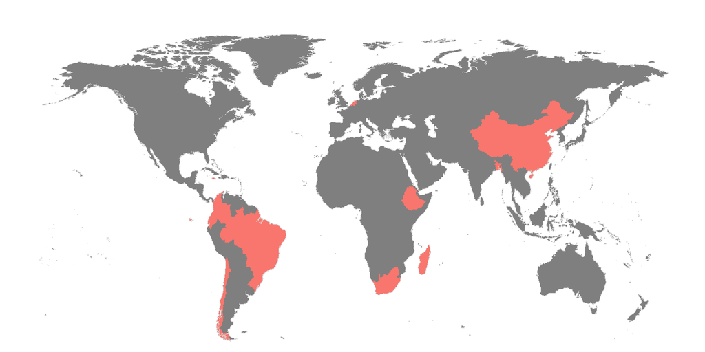

```r
map.world = map_data(map='world')
map.world$value <- NA
map.world$value <- ifelse(map.world$region =="Bangladesh", "skyblue1", map.world$value)
map.world$value <- ifelse(map.world$region =="Brazil", "skyblue1", map.world$value)
map.world$value <- ifelse(map.world$region =="Chile", "skyblue1", map.world$value)
map.world$value <- ifelse(map.world$region =="China", "skyblue1", map.world$value)
map.world$value <- ifelse(map.world$region =="Colombia", "skyblue1", map.world$value)
map.world$value <- ifelse(map.world$region =="Ecuador", "skyblue1", map.world$value)
map.world$value <- ifelse(map.world$region =="Ethiopia", "skyblue1", map.world$value)
map.world$value <- ifelse(map.world$region =="Jamaica", "skyblue1", map.world$value)
map.world$value <- ifelse(map.world$region =="Madagascar", "skyblue1", map.world$value)
map.world$value <- ifelse(map.world$region =="Netherlands", "skyblue1", map.world$value)
map.world$value <- ifelse(map.world$region =="South Africa", "skyblue1", map.world$value)

ggplot() +
  borders("world", colour = "gray85", fill = "gray80") +
  geom_map(data = map.world, map = map.world, aes(
    map_id = region,
    fill=value
  )) +
  theme_map() +
  coord_cartesian(ylim = c(-50, 90)) +
  theme(legend.position = "none")
```

(ref:worldmap) Coverage of countries included in the study.

The GCDG data comprises of birth cohorts, impact evaluation studies and instrument evaluation studies. Table @ref(tab:cohorts) displays a brief overview of the instruments used in each sub-study.

(#tab:cohorts) Overview of instruments administered in the cohorts.

| Cohort | `by` | `den` | `gri` | `bat` | `vin` | `ddi` | `bar` | `tep` | `asq` | `sbi` |
| --- | --- | --- | --- | --- | --- | --- | --- | --- | --- | --- |
| Bangladesh | x |  |  |  |  |  |  |  |  |  |
| Brazil 1 |  | x |  |  |  |  |  |  |  |  |
| Brazil 2 |  |  |  | x |  |  |  |  |  |  |
| Chile 1 | x |  |  |  |  |  |  |  |  |  |
| Chile 2 |  |  |  | x |  |  |  | x |  |  |
| China | x |  |  |  |  |  |  |  |  |  |
| Colombia 1 | x |  |  |  |  |  |  |  |  |  |
| Colombia 2 | x | x |  | x |  |  |  |  | x |  |
| Ecuador |  |  |  |  |  |  | x |  |  |  |
| Ethiopia | x |  |  |  |  |  |  |  |  |  |
| Jamaica 1 |  |  | x |  |  |  |  |  |  |  |
| Jamaica 2 |  |  | x |  |  |  |  |  |  |  |
| Madagascar |  |  |  |  |  |  |  |  |  | x |
| Netherlands 1 |  |  |  |  |  | x |  |  |  |  |
| Netherlands 2 |  |  |  |  |  | x |  |  |  |  |
| South Africa | x |  | x |  | x |  |  |  |  |  |

## Cohort descriptions

The **Bangladesh** study (GCDG-BGD-7MO) was an impact evaluation study including 1862 children around the age of 18 months. The Bayley Scale for Infant and Toddler Development-II (`by2`) was administered and long-term follow-up data were available for the Wechsler Preschool and Primary Scale of Intelligence (WPPSI) at 5 years [@Tofail2008].

The **Brazil 1** study (GCDG-BRA-1) was a birth-cohort with 3 measurement moments: 644 children at 3 months, 1412 children at 6 months and 1362 children at 12 months. In each round, the Denver Developmental Screening Test-II (`den`) was administered. Long-term follow-up data were available for the Wechsler Adult Intelligence Scale (WAIS) at 18 years [@Victora2006].

The **Brazil 2** study (GCDG-BRA-2) was a birth-cohort with measurements of 3907 children at 12 months and 3869 children at 24 months. On both occasions the Battelle Development Inventory (`bat`) was administered [@Moura2010].

The **Chile 1** study (GCDG-CHL-1) was an impact evaluation study of 128 children assessed at 6 months, 1732 children at 12 months and 279 at 18 months. The `by1` was administered at each wave. Long-term follow-up data were available for the WPPSI at 5-6 years [@Lozoff2003].

The **Chile 2** study (GCDG-CHL-2) was a birth-cohort of 4869 children who were administered the Battelle Developmental Inventory (`bat`) at 7-23 months and 9201 children who were administered the Test de Desarrollo Psicomotor (`tep`) at 24-58 months. For the latter group, follow-up data were available for the Peabody Picture Vocabulary Test (PPVT) at 5-6 years [@conteras2015].

The **China** study (GCDG-CHN) was an impact evaluation study that contained 990 children assessed with the by3 at 18 months [@Lozoff2016].

The **Colombia 1** study (GCDG-COL-LT45M) was an impact evaluation study that comprised two waves, wave 1 contained 704 children at 12-24 months and wave 2 631 children at 24-41 months. The `by3` was administered at each wave. Long-term follow-up data were available for PPVT at 4-6 years [@Attanasio2014].

The **Colombia 2** study (GCDG-COL-LT42M) was an instrument validation study where all 1311 children aged 6-42 months were administered the by3. For a subgroup of 658 children the den, the Ages and Stages Questionnaire (`asq`) and the `bat` screener were administered as well. Long-term follow-up data were available for the Fifth Wechsler Intelligence Scale for Children (WISC-V) and the PPVT [@Rubio-Codina2016].

In **Ecuador** an impact evaluation study (GCDG-ECU) was performed for 667 children between 0-35 months where the Barrera Moncada (`bar`) was administered. Long-term follow-up data were available for the PPVT at 5-8 and 9-12 years [@Paxson2010].

The **Ethiopia** study (GCDG-ETH) was a birth-cohort with 193 children of 12 months in the first wave, 440 children of 30 months at the second wave and 456 children of 42 months at the third wave. At each wave the `by3` was administered. Long-term follow-up data were available for the PPVT at 10-11 years [@Hanlon2009].

The **Jamaica 1** study (GCDG-JAM-LBW) was an impact evaluation study were the Griffiths Mental Development Scales (`gri`) were administered to 225 children of 15 months at the first wave, and 218 children of 24 months at the second wave. Long-term follow-up data were available for WPPSI and PPVT at 6 years [@Walker2004].

The **Jamaica 2** study (GCDG-JAM-STUNTED) was an impact evaluation study were the `gri` were administered to 159 children at 9-24 months, 21-36 months and at 33-48 months. Long-term follow-up data were available for `sbi`, Raven’s Coloured Progressive Matrices (Ravens), and PPVT at 7-8 years and the WAIS at 17-18 years [@Grantham-McGregor1991].

The **Madagascar** study (GCDG-MDG) was an impact evaluation study where the `sbi` was administered to 205 children aged 34-42 months. Long-term follow-up data were available for `sbi` and PPVT at 7-11 years [@Fernald2011].

The **Netherlands 1** study (GCDG-NLD-SMOCC) was an instrument validation study with a total of 9 waves. At each wave the Dutch Developmental Instrument (`ddi`) (In the Netherlands known as Van Wiechenschema) was administered. The first wave included 1985 children at 1 month, wave 2 1807 children at 2 months, wave 3 1963 children at 3 months, wave 4 1919 children at 6 months, wave 5 1881 children at 9 months, wave 6 1802 children at 12 months, wave 7 1776 children at 15 months, wave 8 1787 children at 18 months, and wave 9 1815 children at 24 months [@herngreen1992].

The **Netherlands 2** study (GCDG-NLD-2) was an instrument validation study with a total of five waves. At each wave the `ddi` was administered. Wave 1 included 1016 children at 24 months, wave 2 995 children at 30 months, wave 3 1592 children at 36 months, wave 4 1592 children at 42 months, and wave 5 1024 children at 48 months [@doove2010].

The **South Africa** study (GCDG-ZAF) was a birth cohort with four waves. The first wave included 485 children and second wave 275 children, who were assessed at 6 and 12 months, respectively, with the `by1` and the `gri`. The third wave included 1802 children and the fourth wave 1614 children, assessed at 24 and 48 months, respectively, with the Vineland Social Maturity Scale (`vin`) [@Richter2007].

## Instruments

The **Bayley Scales for Infant and Toddler Development (`by1`,`by2`, `by3`)** aim to assess infants and toddlers, aged 1-42 months. The current version is the `by3`, but in GCDG cohorts earlier version were also used (i.e. `by1` and `by2`) [@bayley1969][@bayley1993][@bayley2006]. The 326 items of the `by3` measure three domains: Cognitive items, Motor items (with fine and gross motor items) and Language items (with expressive and receptive items). The `by2` contains 277 items and has two additional subscales: Social-Emotional and Adaptive Behavior. by1 contains 229 items.

The **Denver Developmental Screening Test (`den`)** is aimed to identify developmental problems in children up to age six. The 125 dichotomous test items are distributed over the age range from birth to six years. The Denver covers four domains: personal-social, fine motor and adaptive, language, and gross motor. The test items are all directly observed by an examiner and are not dependent on parent report [@frankenburg1992] [@frankenburg1990].

The **Griffiths Mental Development Scales (`gri`)** measure the rate of development in infants and young children in six developmental areas: loco motor, personal-social, hearing and language, eye and hand coordination, performance and practical reasoning [@griffiths1967].

The **Battelle Developmental Inventory (`bat`)** measures key developmental skills in children from birth to 7 years, 11 months. The instrument contains 450 items distributed over five domains: adaptive, personal-social, communication, motor, and cognitive [@newborg2005].

The **Vineland Social Maturity Scale (`vin`)** is a test to assess social competence. The instrument contains eight subscales that measure communication skills, general self-help ability, locomotion skills, occupation skills, self-direction, self-help eating, self-help dressing and socialization skills [@doll1953].

The **Dutch Developmental Instrument (`ddi`)** measures early child development during the ages 0-4 years. The instrument consists of 75 milestone items that are distributed over three domains: fine motor, adaptive, personal and social behavior; communication; and gross motor [@schlesinger1981].

The **Barrera Moncada (`bar`)** is a Spanish instrument that measures the growth and psychological development of children [@barrera1981].

The **Test de Desarrollo Psicomotor (`tep`)** is an instrument to evaluate toddlers aged 2 to 5 years on their development. The items are distributed over three sub-tests: 16 items assess coordination; 24 items assess language skills and 12 items assess motor skills [@haeussler1999].

The **Ages and Stages Questionnaire (`asq`)** measures developmental progress in children between 2 months and 5,5 years. The instrument assess development in five areas: personal social, gross motor, fine motor, problem solving and communication. The `asq` contains sets of 30 items in 21 age intervals and is completed by the caregiver [@squires2009].

The **Stanford Binet Intelligence Scales (`sbi`)** is a cognitive ability and intelligence test to diagnose developmental deficiencies in young children. The items are distributed over five subtests: fluid reasoning, knowledge, quantitative reasoning, visual-spatial processing and working memory [@roid2003][@hagen1986].